# Homework - wk6d3

# MVP

## Task 1

```r
library(tidyverse)
library(janitor)
library(infer)
```

```r
house_data <- read_csv("data/ames.csv") %>%
  clean_names()
```

```r
glimpse(house_data)
```

```
Rows: 2,930
Columns: 82
$ order           <dbl> 1, 2, 3, 4, 5, 6, 7, 8, 9, 10, 11, 12, 13, 14, 15, 16, 17, …
$ pid             <dbl> 526301100, 526350040, 526351010, 526353030, 527105010, 5271…
$ ms_sub_class    <dbl> 20, 20, 20, 20, 60, 60, 120, 120, 120, 60, 60, 20, 60, 20, …
$ ms_zoning       <chr> "RL", "RH", "RL", "RL", "RL", "RL", "RL", "RL", "RL", "RL",…
$ lot_frontage    <dbl> 141, 80, 81, 93, 74, 78, 41, 43, 39, 60, 75, NA, 63, 85, NA…
$ lot_area        <dbl> 31770, 11622, 14267, 11160, 13830, 9978, 4920, 5005, 5389, …
$ street          <chr> "Pave", "Pave", "Pave", "Pave", "Pave", "Pave", "Pave", "Pa…
$ alley           <chr> NA, NA, NA, NA, NA, NA, NA, NA, NA, NA, NA, NA, NA, NA, NA,…
$ lot_shape       <chr> "IR1", "Reg", "IR1", "Reg", "IR1", "IR1", "Reg", "IR1", "IR…
$ land_contour    <chr> "Lvl", "Lvl", "Lvl", "Lvl", "Lvl", "Lvl", "Lvl", "HLS", "Lv…
$ utilities       <chr> "AllPub", "AllPub", "AllPub", "AllPub", "AllPub", "AllPub",…
$ lot_config      <chr> "Corner", "Inside", "Corner", "Corner", "Inside", "Inside",…
$ land_slope      <chr> "Gtl", "Gtl", "Gtl", "Gtl", "Gtl", "Gtl", "Gtl", "Gtl", "Gt…
```

[output cut: 69 more lines]

```r
skimr::skim(house_data)
```

```
── Data Summary ────────────────────────
                           Values
Name                       house_data
Number of rows             2930
Number of columns          82
_______________________
Column type frequency:
  character                43
  numeric                  39
________________________
Group variables            None
```

|  | skim_variable | n_missing | complete_rate | min | max | empty | n_unique | whitespace |
| --- | --- | --- | --- | --- | --- | --- | --- | --- |
| 1 | ms_zoning | 0 | 1.00000000 | 2 | 7 | 0 | 7 | 0 |
| 2 | street | 0 | 1.00000000 | 4 | 4 | 0 | 2 | 0 |
| 3 | alley | 2732 | 0.06757679 | 4 | 4 | 0 | 2 | 0 |
| 4 | lot_shape | 0 | 1.00000000 | 3 | 3 | 0 | 4 | 0 |
| 5 | land_contour | 0 | 1.00000000 | 3 | 3 | 0 | 4 | 0 |
| 6 | utilities | 0 | 1.00000000 | 6 | 6 | 0 | 3 | 0 |
| 7 | lot_config | 0 | 1.00000000 | 3 | 7 | 0 | 5 | 0 |
| 8 | land_slope | 0 | 1.00000000 | 3 | 3 | 0 | 3 | 0 |
| 9 | neighborhood | 0 | 1.00000000 | 5 | 7 | 0 | 28 | 0 |
| 10 | condition_1 | 0 | 1.00000000 | 4 | 6 | 0 | 9 | 0 |

[output cut: 33 more lines]

|  | skim_variable | n_missing | complete_rate | mean | sd | p0 | p25 | p50 | p75 | p100 | hist |
| --- | --- | --- | --- | --- | --- | --- | --- | --- | --- | --- | --- |
| 1 | order | 0 | 1.0000000 | 1.465500e+03 | 8.459625e+02 | 1 | 7.33250e+02 | 1465.5 | 2197.75 | 2930 | ▇▇▇▇▇ |
| 2 | pid | 0 | 1.0000000 | 7.144645e+08 | 1.887308e+08 | 526301100 | 5.28477e+08 | 535453620.0 | 907181097.50 | 1007100110 | ▇▁▁▆▂ |
| 3 | ms_sub_class | 0 | 1.0000000 | 5.738737e+01 | 4.263802e+01 | 20 | 2.00000e+01 | 50.0 | 70.00 | 190 | ▇▅▂▁▁ |
| 4 | lot_frontage | 490 | 0.8327645 | 6.922459e+01 | 2.336533e+01 | 21 | 5.80000e+01 | 68.0 | 80.00 | 313 | ▇▃▁▁▁ |
| 5 | lot_area | 0 | 1.0000000 | 1.014792e+04 | 7.880018e+03 | 1300 | 7.44025e+03 | 9436.5 | 11555.25 | 215245 | ▇▁▁▁▁ |
| 6 | overall_qual | 0 | 1.0000000 | 6.094881e+00 | 1.411026e+00 | 1 | 5.00000e+00 | 6.0 | 7.00 | 10 | ▁▂▇▅▁ |
| 7 | overall_cond | 0 | 1.0000000 | 5.563140e+00 | 1.111537e+00 | 1 | 5.00000e+00 | 5.0 | 6.00 | 9 | ▁▁▇▅▁ |
| 8 | year_built | 0 | 1.0000000 | 1.971356e+03 | 3.024536e+01 | 1872 | 1.95400e+03 | 1973.0 | 2001.00 | 2010 | ▁▂▃▆▇ |
| 9 | year_remod_add | 0 | 1.0000000 | 1.984267e+03 | 2.086029e+01 | 1950 | 1.96500e+03 | 1993.0 | 2004.00 | 2010 | ▅▂▂▃▇ |
| 10 | mas_vnr_area | 23 | 0.9921502 | 1.018968e+02 | 1.791126e+02 | 0 | 0.00000e+00 | 0.0 | 164.00 | 1600 | ▇▁▁▁▁ |

[output cut: 29 more lines]

## Task 2

Investigate the distribution of lot_area. Is the distribution roughly normal? If not, what problems do you find?

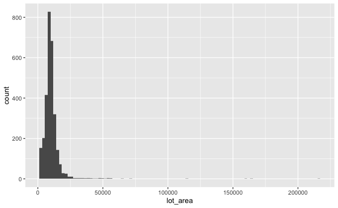

```r
house_data %>%
  ggplot(aes(x = lot_area)) +
  geom_histogram(bins = 100)
```

```r
e1071::skewness(house_data$lot_area, type = 1)
```

```
[1] 12.81433
```

The `house_lot` data is very highly positively skewed.

There looks to be a really long tail to the right, if these values were removed, maybe the bulk of the data would look better.

```r
house_data %>%
  select(lot_area) %>%
  arrange(desc(lot_area))
```

| lot_area |
| --- |
| 215245 |
| 164660 |
| 159000 |
| 115149 |
| 70761 |
| 63887 |
| 57200 |
| 56600 |
| 53504 |
| 53227 |

[output cut: 990 more lines]

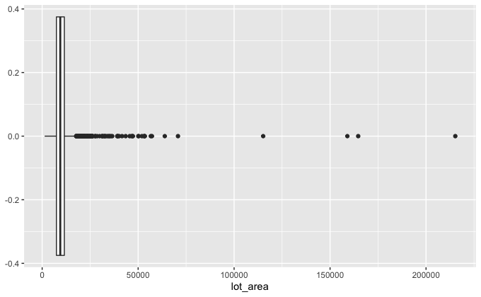

```r
house_data %>%
  ggplot(aes(x = lot_area)) +
  geom_boxplot()
```

## Tasks 3 + 4

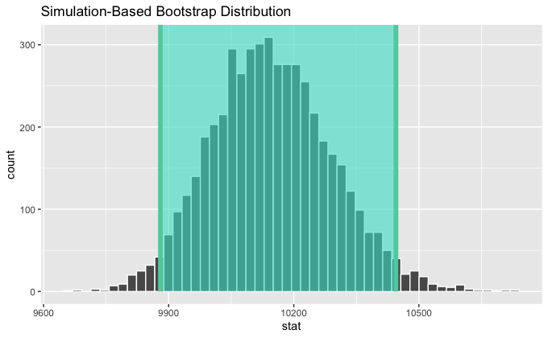

```r
bootstrapped_house_lot <- house_data %>%
  specify(response = lot_area) %>%
  generate(reps = 5000, type = "bootstrap") %>%
  calculate(stat = "mean")

lot_area_95ci <- bootstrapped_house_lot %>%
  get_ci(level = 0.95, type = "percentile")

bootstrapped_house_lot %>%
  visualise(bins = 50) +
  shade_ci(endpoints = lot_area_95ci)
```

## Task 5

```r
# 99 ci
lot_area_99ci <- bootstrapped_house_lot %>%
  get_ci(level = 0.99, type = "percentile")
```

[output not shown]

The 99% CI is broader, because it contains more of the data.

## Task 6

```r
lot_area_99ci %>%
  mutate(mean_boot = mean(bootstrapped_house_lot$stat, na.rm = TRUE), .before = lower_ci) %>%
  mutate(mean_orig = mean(house_data$lot_area, na.rm = TRUE), .before = mean_boot)
```

| mean_orig | mean_boot | lower_ci | upper_ci |
| --- | --- | --- | --- |
| 10147.92 | 10147.24 | 9801.309 | 10562.93 |

So we can say that we estimate the mean house lot area to be 10,148 square metres with a 99% CI of [9,801, 10,563] square metres. *(If units = m2!!)*

# Extension

Calculate a point estimate and 95% CI for the proportion of houses in the data built before 1920. Does the number of reps you use matter? [Investigate reps from 200 up to 50000, memory of your laptop permitting].

Try reps: 200, 1000, 10000, 40000 (if laptop can do it)

proportion of houses in the data built before 1920 – var: year_built (), condition: < 1920

```r
# proportion built before 1920 in this sample
prop_1920_original <- house_data %>%
  summarise(prop = sum(year_built < 1920)/n()) %>%
  pull()

prop_1920_original
```

```
[1] 0.06006826
```

So from our sample, 6% houses were built before 1920.

Let’s find our CI for this using bootstrapping:

```r
## successful attempt
resample_200reps <- house_data %>%
  mutate(built_before_1920 = if_else(
    year_built < 1920, "Yes", "No"
  ), .before = order) %>%
  specify(response = built_before_1920, success = "Yes") %>%
  generate(reps = 200, type = "bootstrap") %>%
  calculate(stat = "prop")
```

```r
## failed attempt
resample_200_x <- house_data %>%
  specify(response = year_built, success = toString(rlang::is_true(.$year_built<1920))) %>%
  generate(reps = 200, type = "bootstrap") %>%
  calculate(stat = "prop")
```

```
Error: `success` should only be specified if the response is a categorical variable.
```

“Error: `success` should only be specified if the response is a categorical variable.”

```r
ci_200reps <- resample_200reps %>%
  get_ci(level = 0.95, type = "percentile")

prop_200reps <- resample_200reps %>%
  summarise(prop = mean(stat)) %>%
  pull()

ci_200reps
```

| lower_ci | upper_ci |
| --- | --- |
| 0.05287543 | 0.06962457 |

```r
prop_200reps
```

```
[1] 0.06046075
```

```r
prop_1920_original
```

```
[1] 0.06006826
```

## Try increasing reps in the bootstrapping

What if we increase the reps in the bootstrapping?

We cannot increase sample size, since this is always equivalent to our original sample size (~3000 rows of data). But we can increase the number of resamples we take.

Thinking ahead: as reps go up, the CI gets tighter and the mean stat from the resampled data gets closer to the original stat - but I expect there to be a point at which adding reps makes very little difference, particularly as we approach the sample stat (here, proportion) and the limit of R’s decimal calculations. Or maybe the CI keeps getting tighter and tighter and it’s like we’re overfitting our data, relying too heavily on the sample data.

### Function to generate stats table

Write a function:

```r
get_bootstrap_stats <- function(start_reps, increment, steps) {

  results <- tibble("name" = "source_df", "lower_ci" = NA_integer_, "upper_ci" = NA_integer_, "prop" = prop_1920_original)

  for (i in 0:steps) {

  reps <- start_reps + increment*i

  df <- house_data %>%
  mutate(built_before_1920 = if_else(
    year_built < 1920, "Yes", "No"
  ), .before = order) %>%
  specify(response = built_before_1920, success = "Yes") %>%
  generate(reps = reps, type = "bootstrap") %>%
  calculate(stat = "prop")

  ci_95 <- df %>%
  get_ci(level = 0.95, type = "percentile")

  prop <- df %>%
  summarise(prop = mean(stat)) %>%
  pull()

  results_reps <- tibble("name" = as.character(reps), "lower_ci" = ci_95$lower_ci, "upper_ci" = ci_95$upper_ci, "prop" = prop)

  results <- bind_rows(results, results_reps)
  }

  return(results)

}
```

```r
get_bootstrap_stats_multiply <- function(start_reps, multiplier, steps) {

  results <- tibble("name" = "source_df", "lower_ci" = NA_integer_, "upper_ci" = NA_integer_, "prop" = prop_1920_original)

  for (i in 0:steps) {

  reps <- start_reps * (i * multiplier)

  df <- house_data %>%
  mutate(built_before_1920 = if_else(
    year_built < 1920, "Yes", "No"
  ), .before = order) %>%
  specify(response = built_before_1920, success = "Yes") %>%
  generate(reps = reps, type = "bootstrap") %>%
  calculate(stat = "prop")

  ci_95 <- df %>%
  get_ci(level = 0.95, type = "percentile")

  prop <- df %>%
  summarise(prop = mean(stat)) %>%
  pull()

  results_reps <- tibble("name" = as.character(reps), "lower_ci" = ci_95$lower_ci, "upper_ci" = ci_95$upper_ci, "prop" = prop)

  results <- bind_rows(results, results_reps)
  }

  return(results)

}
```

#### Results table:

| name | lower_ci | upper_ci | prop |
| --- | --- | --- | --- |
| source_df | NA | NA | 0.06006826 |
| 1000 | 0.05220990 | 0.06894198 | 0.06018089 |
| 4000 | 0.05153584 | 0.06825939 | 0.05998567 |
| 7000 | 0.05153584 | 0.06894198 | 0.06016324 |
| 10000 | 0.05153584 | 0.06894198 | 0.06010102 |
| 13000 | 0.05153584 | 0.06860068 | 0.06007852 |
| 16000 | 0.05153584 | 0.06860068 | 0.06007440 |
| 19000 | 0.05153584 | 0.06894198 | 0.06009585 |
| 22000 | 0.05153584 | 0.06860922 | 0.06005597 |
| 25000 | 0.05153584 | 0.06894198 | 0.06005747 |

[output cut: 7 more lines]

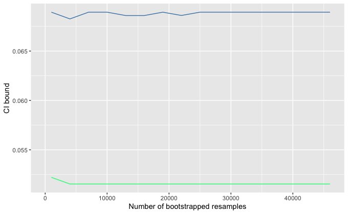

```r
# plot CI bounds
experiment_17s %>%
  mutate(reps = if_else(name == "source_df", 1, as.numeric(name))) %>%
  ggplot() +
  geom_line(aes(x = reps, y = lower_ci), colour = "springgreen") +
  geom_line(aes(x = reps, y = upper_ci), colour = "steelblue") +
  labs(x = "Number of bootstrapped resamples", y = "CI bound")
```

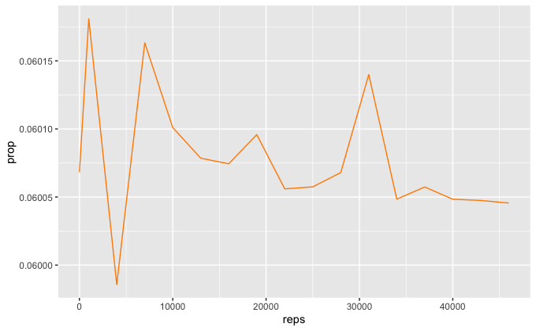

```r
# plot mean props
experiment_17s %>%
  mutate(reps = if_else(name == "source_df", 1, as.numeric(name))) %>%
  ggplot() +
  geom_line(aes(x = reps, y = prop), colour = "darkorange")
```

At lower number of resamples, the CIs vary; once 25000 and above reps, they have stabilised <- the sensitivity of our CIs to bootstrapping resamples.

#### Results table: 500, 3000, 5500, …, 13000

| name | lower_ci | upper_ci | prop |
| --- | --- | --- | --- |
| source_df | NA | NA | 0.06006826 |
| 500 | 0.05153584 | 0.06825939 | 0.05974949 |
| 3000 | 0.05187713 | 0.06894198 | 0.06011229 |
| 5500 | 0.05153584 | 0.06860068 | 0.06001818 |
| 8000 | 0.05153584 | 0.06894198 | 0.06006711 |
| 10500 | 0.05187713 | 0.06894198 | 0.06007284 |
| 13000 | 0.05153584 | 0.06860068 | 0.06000895 |

### Function to visualise dist & shade CIs

```r
plot_bootstrap <- function(reps) {

  df <- house_data %>%
  mutate(built_before_1920 = if_else(
    year_built < 1920, "Yes", "No"
  ), .before = order) %>%
  specify(response = built_before_1920, success = "Yes") %>%
  generate(reps = reps, type = "bootstrap") %>%
  calculate(stat = "prop")

  ci_95 <- df %>%
  get_ci(level = 0.95, type = "percentile")

  # prop <- df %>%
  # summarise(prop = mean(stat)) %>%
  # pull()

  plot <- df %>%
    visualise(bins = 50) +
    shade_ci(endpoints = ci_95) #+
    # labs(subtitle = str_c("reps: ",reps,
    #                       "; 95% CI: [",round(ci_95[1],5),",",round(ci_95[2],5),
    #                       "]; Prop:",round(prop,5)))
    #
  print(plot)
}
```

#### Results: 100, 500, 1000, 5000, 25000

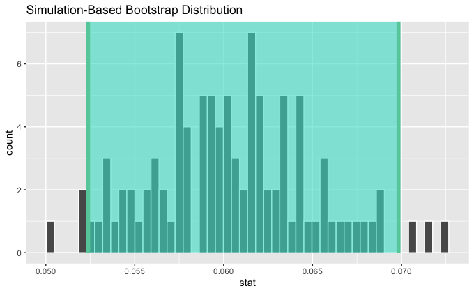

```r
plot_bootstrap(100)
```

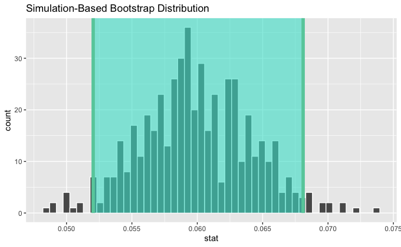

```r
plot_bootstrap(500)
```

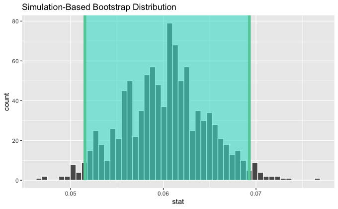

```r
plot_bootstrap(1000)
```

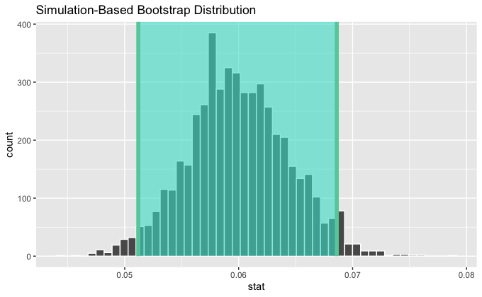

```r
plot_bootstrap(5000)
```

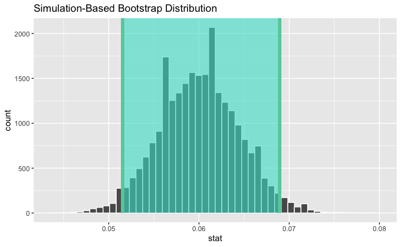

```r
plot_bootstrap(25000)
```

## Interpretation

### Old, but don’t overwrite

| reps | ci_95$lower_ci | ci_95$upper_ci | prop |
| --- | --- | --- | --- |
| 1000 | 0.05119454 | 0.06962457 | 0.06000785 |

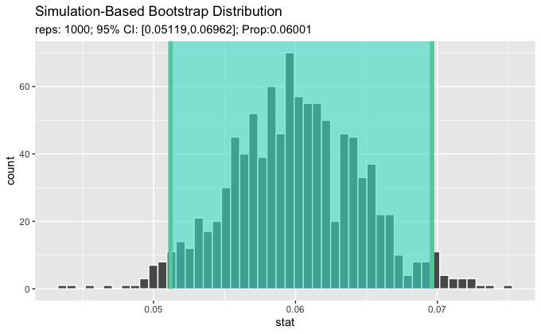

| reps | ci_95$lower_ci | ci_95$upper_ci | prop |
| --- | --- | --- | --- |
| 5000 | 0.05119454 | 0.06894198 | 0.0600516 |

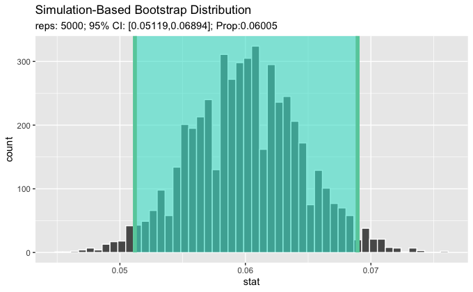

```r
bootstrap_my_bb1920(50000)
```

[output not shown]

[output not shown]

[figure not shown]

| reps | ci_95$lower_ci | ci_95$upper_ci | prop |
| --- | --- | --- | --- |
| 10000 | 0.05153584 | 0.06894198 | 0.06005713 |

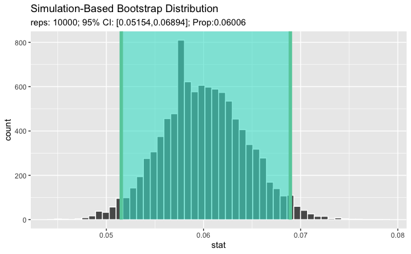

| reps | ci_95$lower_ci | ci_95$upper_ci | prop |
| --- | --- | --- | --- |
| 20000 | 0.05153584 | 0.06894198 | 0.06007845 |

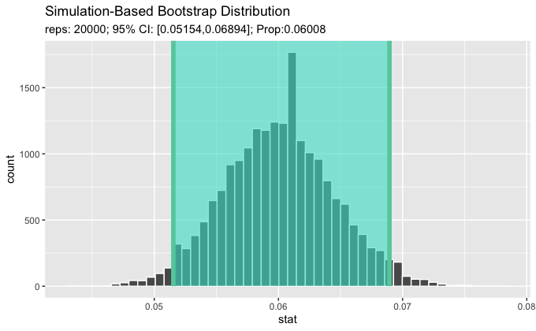

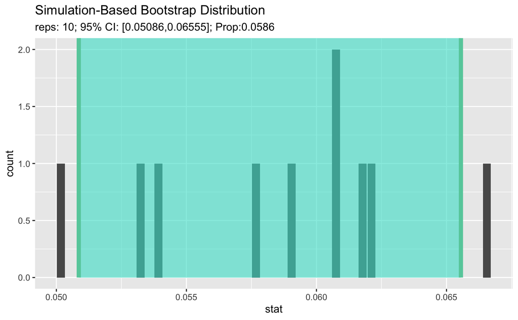

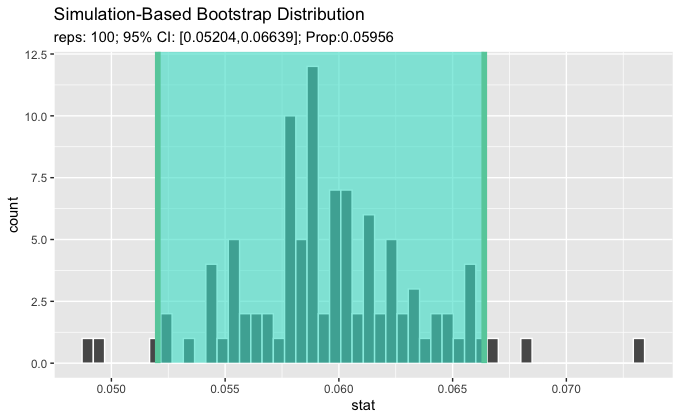

```r
table <- bind_rows(bootstrap_my_bb1920(10)$results, bootstrap_my_bb1920(100)$results)
```

```r
table
```

[output not shown]